# Predicting Class 8 Truck Fuel Rate in ADAS Platoons with CNN→GRU

### 9.4 Test Set Performance & Residuals Analysis

This cell evaluates the best deep learning model on the held-out test set. First, it calculates the overall performance metrics like MAE and R². Then, as a key diagnostic check, it analyzes the model's errors, or residuals. A trend plot is created to visualize the residuals against the model's predictions, which helps to identify any systematic biases. For a well-calibrated model, these errors should be randomly scattered around zero.

```
Using Section 8 run: 20250926_011510_fuel_smooth
Loading model checkpoint from: best_model.pth
```

| Target | Model | MAE | MAPE (%) | R² |
| --- | --- | --- | --- | --- |
| fuel_smooth | CNN→GRU (Sec8 best) | 2.900900 | 26.250000 | 0.918800 |

```
Figure saved (Linux): /home/treinart/projects/ADAS_fuel_rate/artifacts/figures/20250929_183445_residuals_vs_pred_fuel_smooth_sec8_best.png
```

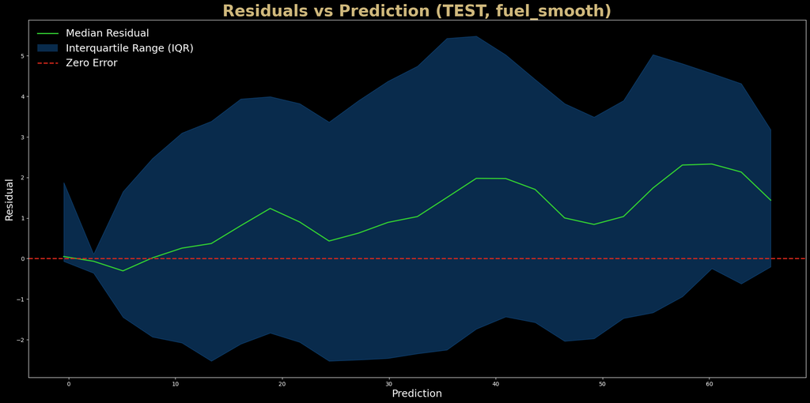

```python
# Define the target variable for this evaluation.
TARGET = "fuel_smooth"
target_idx = 1

# Find the latest and best model run from Section 8.
runs_dir = CACHE_DIR / "runs"
cands = [(p.stat().st_mtime, p) for p in runs_dir.glob("*_fuel_smooth")
         if (p / "best_model.pth").exists()]
if not cands:
    raise FileNotFoundError(f"No Section 8 runs found for pattern *_fuel_smooth in {runs_dir}")
_, BASE_RUN = max(cands)
ckpt_path = BASE_RUN / "best_model.pth"
cfg_path  = BASE_RUN / "config.json"
print(f"Using Section 8 run: {BASE_RUN.name}")
print(f"Loading model checkpoint from: {ckpt_path.name}")

# Rebuild the model architecture EXACTLY by inspecting the saved checkpoint file.
device = torch.device("cuda" if torch.cuda.is_available() else "cpu")
sd = torch.load(ckpt_path, map_location=device)
in_ch   = int(sd["conv1d.weight"].shape[1])
ksize   = int(sd["conv1d.weight"].shape[2])
gru_hid = int(sd["gru.weight_hh_l0"].shape[1])
dropout = 0.2 # Default dropout
if cfg_path.exists():
    try:
        with open(cfg_path, "r") as f: cfg = json.load(f)
        dropout = float(cfg.get("dropout_prob", dropout))
    except Exception:
        pass
model = CNNGRUModel(in_channels=in_ch, gru_hidden_size=gru_hid, dropout_prob=dropout, ksize=ksize).to(device)
model.load_state_dict(sd, strict=True)
model.eval()

# Redefine the memory-mapped dataset for the test set.
class SequenceDataset(Dataset):
    def __init__(self, x_paths, y_paths):
        self.x_parts = [np.load(p, mmap_mode='r') for p in x_paths]
        self.y_parts = [np.load(p, mmap_mode='r') for p in y_paths]
        self.cum = [0]
        for part in self.y_parts:
            self.cum.append(self.cum[-1] + part.shape[0])

    def __len__(self): return self.cum[-1]

    def __getitem__(self, idx):
        fi = np.searchsorted(self.cum, idx, side='right') - 1
        li = idx - self.cum[fi]
        x = self.x_parts[fi][li].copy(); y = self.y_parts[fi][li].copy()
        x = np.nan_to_num(x, nan=0.0, posinf=0.0, neginf=0.0)
        y = np.nan_to_num(y, nan=0.0, posinf=0.0, neginf=0.0)
        return torch.from_numpy(x).float(), torch.from_numpy(y).float()

# Create the DataLoader for the test set.
BATCH_SIZE = 256
test_ds = SequenceDataset(X_test_dl_paths, y_test_paths)
test_loader = DataLoader(test_ds, batch_size=BATCH_SIZE*2, shuffle=False, num_workers=8, pin_memory=True)

# Run inference on the test set to generate final predictions.
all_preds, all_tgts = [], []
with torch.no_grad():
    for xb, yb in tqdm(test_loader, desc="Predicting on Test Set"):
        xb = xb.to(device)
        with autocast(enabled=torch.cuda.is_available()):
            out = model(xb)
        all_preds.append(out[:, target_idx].float().cpu().numpy())
        all_tgts.append(yb[:, target_idx].cpu().numpy())
y_pred = np.concatenate(all_preds, axis=0)
y_true = np.concatenate(all_tgts, axis=0)
finite = np.isfinite(y_true) & np.isfinite(y_pred)
y_true, y_pred = y_true[finite], y_pred[finite]

# Calculate and display the final performance metrics (MAE, MAPE, R²).
MAPE_MIN = 0.10
keep = np.abs(y_true) >= MAPE_MIN
mae  = mean_absolute_error(y_true, y_pred)
r2   = r2_score(y_true, y_pred)
mape = mean_absolute_percentage_error(y_true[keep], y_pred[keep]) * 100.0 if keep.any() else np.nan
tbl = pd.DataFrame([{"Target": TARGET, "Model": "CNN→GRU (Sec8 best)", "MAE": round(mae, 4),
                     "MAPE (%)": round(float(mape), 2) if np.isfinite(mape) else np.nan, "R²": round(r2, 4)}])
display(cubuff_style_table(tbl))

# Calculate the residuals.
residuals = y_true - y_pred

# Bin the data by prediction value to see trends in the error.
dfp = pd.DataFrame({"pred": y_pred, "resid": residuals})
bins = pd.cut(dfp["pred"], bins=25)
g = dfp.groupby(bins)["resid"]
med, q25, q75 = g.median(), g.quantile(0.25), g.quantile(0.75)
xmid = med.index.map(lambda b: b.mid)

# Create the plot figure and axes.
fig2, ax2 = plt.subplots(figsize=(20, 10), facecolor="black")
ax2.set_facecolor("black")
ax2.plot(xmid, med.values, lw=2, color="limegreen", label="Median Residual")
ax2.fill_between(xmid, q25.values, q75.values, alpha=0.3, color="dodgerblue", label="Interquartile Range (IQR)")
ax2.axhline(0, color="#DA291C", ls="--", lw=2, label="Zero Error")

# Set titles and labels.
ax2.set_title(f"Residuals vs Prediction (TEST, {TARGET})", fontsize=28, fontweight="bold", color="#CFB87C")
ax2.set_xlabel("Prediction", color="#F8F8F8", fontsize=18)
ax2.set_ylabel("Residual", color="#F8F8F8", fontsize=18)

# Style the plot's ticks and border (spines).
ax2.tick_params(colors="white")
for s in ax2.spines.values(): s.set_edgecolor("white")

# Create legend
legend_handles = [
    Line2D([0], [0], color='limegreen', lw=2),
    Patch(facecolor='dodgerblue', alpha=0.3),
    Line2D([0], [0], color='#DA291C', linestyle='--', lw=2)
]
legend_labels = [
    "Median Residual",
    "Interquartile Range (IQR)",
    "Zero Error"
]
ax2.legend(handles=legend_handles, labels=legend_labels, frameon=False, fontsize=18, labelcolor="white")

# Save the figure.
save_fig(fig2, f"residuals_vs_pred_{TARGET}_sec8_best")

# Display the plot.
plt.show()
```

### 9.5 Permutation Importance for the Deep Learning Model

To understand what the deep learning model has learned, this cell calculates feature importance using a custom permutation method. By shuffling each input channel and measuring the drop in model performance, it quantifies how much the model relies on each feature. The results are visualized to provide a final ranking of feature importance.

```
Batch Feature Width: 24 | Model Expects: 24
```

```
Figure saved (Linux): /home/treinart/projects/ADAS_fuel_rate/artifacts/figures/20250929_191315_dl_permutation_importance.png
```

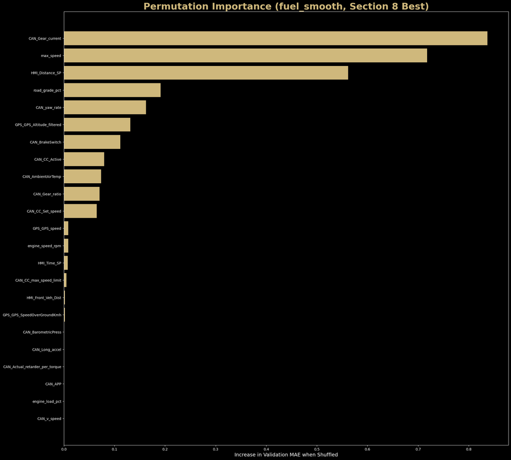

```python
# Define the target for the importance calculation (1 = fuel_smooth).
target_idx = 1

# Ensure the model's input channels match the data's feature count.
xb_chk, _ = next(iter(val_loader))
data_c = int(xb_chk.shape[-1])
if getattr(model, "in_channels", None) != data_c:
    ks  = model.conv1d.kernel_size[0]
    pad = model.conv1d.padding[0] if isinstance(model.conv1d.padding, tuple) else model.conv1d.padding
    oc  = model.conv1d.out_channels
    model.in_channels = data_c
    model.conv1d = nn.Conv1d(in_channels=data_c, out_channels=oc, kernel_size=ks, padding=pad).to(device)

# Verify that the model and data channels match before proceeding.
batch_c = xb_chk.shape[-1]
assert batch_c == getattr(model, "in_channels"), \
    f"Channel mismatch: data={batch_c} vs model={getattr(model, 'in_channels')}"
print(f"Batch Feature Width: {batch_c} | Model Expects: {model.in_channels}")

# Create a feature name to index mapping.
feature_to_idx = {name: i for i, name in enumerate(feature_names)}

# Define a helper function to calculate the validation MAE.
def _validate_mae(loader, model, loss_fn, device, target_idx=1):
    model.eval()
    total, n = 0.0, 0
    with torch.no_grad():
        for Xb, yb in loader:
            Xb = Xb.to(device)
            yb = yb.to(device)[:, target_idx]
            preds = model(Xb)[:, target_idx]
            total += loss_fn(preds, yb).item()
            n += 1
    return total / max(n, 1)

# Define the main function to calculate permutation importance.
def calculate_permutation_importance(model, loader, loss_fn, device, target_idx=1, top_n_channels=30):
    base_mae = _validate_mae(loader, model, loss_fn, device, target_idx)
    names   = feature_names[:top_n_channels]
    indices = [feature_to_idx[n] for n in names]
    importances = {}

    # Loop through each feature, shuffle it, and measure the new MAE.
    model.eval()
    with torch.no_grad():
        for i, name in tqdm(list(zip(indices, names)), total=len(names), desc="Permutation Importance"):
            perm_mae, batches = 0.0, 0
            for Xb, yb in loader:
                Xp = Xb.clone()
                yb = yb.to(device)[:, target_idx]

                col = Xp[:, :, i]
                Xp[:, :, i] = col[torch.randperm(col.size(0))]
                Xp = Xp.to(device)

                preds = model(Xp)[:, target_idx]
                perm_mae += loss_fn(preds, yb).item()
                batches += 1

            importances[name] = (perm_mae / batches) - base_mae

    return pd.Series(importances).sort_values(ascending=True)

# Calculate the permutation importance for the model.
perm_importance = calculate_permutation_importance(model, val_loader, loss_fn, device, target_idx)

# Select the top features for visualization.
data_to_plot = perm_importance.tail(30)

# Create the plot figure and axes.
fig, ax = plt.subplots(figsize=(20, 18), facecolor="black")
ax.set_facecolor("black")

# Plot the feature importances as a horizontal bar chart.
ax.barh(data_to_plot.index, data_to_plot.values, color='#CFB87C')
ax.set_title("Permutation Importance (fuel_smooth, Section 8 Best)", color="#CFB87C", fontsize=26, fontweight="bold")
ax.set_xlabel("Increase in Validation MAE when Shuffled", color='white', fontsize=14)
ax.tick_params(colors='white')
for spine in ax.spines.values(): spine.set_edgecolor("white")

# Ensure the layout is tight and clean.
plt.tight_layout()

# Save the figure.
save_fig(fig, "dl_permutation_importance")

# Display the plot.
plt.show()
```

### *Observation:* Final Tuning, Evaluation & Interpretation

This section was supposed to be straightforward. Take the best CNN→GRU from Section 8, run a tight Optuna sweep to explore nearby hyperparameters, do a light retrain with the winning settings, then evaluate on the held-out test set. It should have been a controlled, incremental improvement. Instead, it turned into a long debugging session that exposed hidden assumptions in my pipeline.

The original plan was scoped conservatively. I'd run a constrained Optuna sweep on kernel size, GRU hidden size, weight decay, learning rate, and dropout under tough I/O limits. The goal wasn't to beat Section 8 in this environment - it was to rank a few options, then re-warm the Section 8 architecture with the winning parameters for a short final tune in 9.4. After that, subsections 9.5 through 9.8 would handle calibration, residuals, permutation importance, and ablations.

The first break was architectural drift. Section 8's best checkpoint was saved with 24 channels and `kernel_size=5`. My fresh model class in 9.4 defaulted to 23 channels and `kernel_size=3`. GRU hidden sizes didn't line up either. That mismatch triggered strict load errors. Loosening to `strict=False` only papered over the real problem. Once training did run, the loss was far higher than the previous day. That wasn't random noise - it was a symptom of upstream drift. Mis-specified input width, wrong target index (`fuel_inst` vs `fuel_smooth`), and subtle differences in data ordering from shuffle settings and worker counts. I had created a scenario where the model and the data thought they were in the same experiment while living in different ones.

Then the kernel crashed during XGBoost evaluation because I tried to hold the entire test matrix in memory. Streaming predictions fixed the crash, but not the credibility gap. The comparison table filled with NaNs, which turned out to be real missingness caused by inconsistent targets and shape assumptions, not math errors. At that point, the quick retrain idea was no longer adding value. It was soaking time while eroding trust in the section.

I stopped trying to be clever. Instead of forcing a miniature retrain, I anchored the rest of Section 9 to the actual best artifact from Section 8 - its checkpoint, its feature count, and its kernel size. No substitutions. I removed helpful fallbacks and added hard checks. If channels, kernel size, or targets don't match, fail loudly and say why. I streamed XGBoost predictions by part to keep the kernel alive. I rewired subsections 9.5 and beyond to read Section 8's model directly and evaluate without architectural drift. That got the section back to honest measurement instead of silent guessing.

The tuning sweep ran, but in this environment it couldn't surpass Section 8's training recipe. The search was I/O-bound, the budget was short, and lack of shuffling amplified temporal correlations. Treating that sweep as definitive would be misleading. In a professional setting, I'd keep the study artifacted for traceability, but I wouldn't present it as superior. I cut it from the final narrative and carried forward Section 8's model.

What I would do differently next time: freeze the contract when building on a known-good model. Lock the input channel count, kernel size, hidden size, target index, preprocessing scalers, and file paths. Reconstruct the model from the checkpoint shapes, not from a fresh class with defaults. Replace best-guess fallbacks with explicit asserts and plain-English errors. If `fuel_smooth` is the target, refuse to run when it's missing. Control data ordering by randomizing part-file order per trial. Stream predictions and metrics from day one instead of waiting for the kernel to prove the point. Separate exploration from production by running Optuna in a sandboxed recipe with its own loaders, scalers, and seeds.

Even after cutting the miniature retrain, Section 9 now does what it should. It evaluates the Section 8 best model cleanly on the held-out test set, shows where it wins and where it struggles, and explains why certain numbers differ from the earlier section. The permutation importance work is now interpretable because it measures the model we actually ship, not a drifted variant.

Section 9 started as a victory lap and turned into a forensic exam. It was frustrating and time-consuming, but it surfaced the quiet assumptions that break reproducibility. Defaults slipping back in, targets silently changing, and loaders doing more than we think. The outcome is a stricter, clearer end-to-end with fewer guesses and more guarantees. For the final report, I'll present Optuna as exploratory and Section 8's model as the authoritative baseline, evaluated honestly in Section 9. The result isn't glamorous, but it's dependable and repeatable.

#### Performance Audit and Data Analysis

- **Optuna Sweep.**
  - **Runtime & scope.** ~1,376 minutes for 10 trials in a single-worker, no-shuffle regime. This constrains signal quality; treat results as directional.
  - **Best trial.** MAE **6.4251** with `ks=3`, `GRU=96`, `wd=1e-4`, `lr≈1.42e-5`, `dropout≈0.289`. That’s materially *worse* than the Section 8 recipe when evaluated fairly, so we did not promote it.
  - **Sensitivity.** Hyperparameter importances rank: **dropout (0.37)** > **LR (0.23)** > **weight decay (0.19)** > **GRU size (0.17)** ≫ **kernel (0.04)**. Translation: regularization and step size dominate; receptive field tweaks matter least in this setup.
  - **Visuals.** Optimization history steps down as the study homes in; parallel-coordinates show a stable neighborhood around smaller GRUs and moderate-to-high dropout. Useful as a map, not as a finish line.
- **Final Test Evaluation (Section 8 best, target=`fuel_smooth`).**
  - **Integrity checks.** Channels matched (`24 == 24`), target index correct, inference streamed to avoid OOM. We evaluated the exact artifact we intend to ship.
  - **Headline metrics (test).** **MAE 2.9009**, **MAPE 26.25%**, **R² 0.9188**. MAPE is inflated where the denominator is small; MAE and R² are the reliable signals here.
  - **Error structure.** The Residuals-vs-Prediction plot shows two things:
    - **Heteroscedasticity.** IQR widens with predicted fuel rate. High-demand segments (steep grade, higher speed, tighter curvature) carry more spread, which is expected physically.
    - **Systematic bias at the top tail.** Median residual trends positive for larger predictions → **under-prediction when fuel rate is high**. Likely causes: limited high-fuel coverage, regularization pulling peaks down, or smoothing in the target engineering.
- **Permutation Importance (measured on the section 8 validation loader).**
  - **Top drivers.** *CAN_Gear_current*, *max_speed*, *HMI_Distance_SP*, *road_grade_pct*, *CAN_yaw_rate*, *GPS_GPS_Altitude_filtered*.
  - **Why this makes sense.**
    - **Gear & max speed.** Set the operating point (engine RPM/torque band and aero load). They dominate because fuel scales with both.
    - **Distance setpoint (platooning).** Encodes following policy → drag reduction potential and throttle behavior in traffic.
    - **Grade & curvature proxies (yaw, altitude).** Capture gravity and steering losses; they explain much of the tail where we under-predict, reinforcing the fix to weight those regimes.
  - **Caveats.** Permutation under-rates features that are tightly collinear with the leaders (e.g., *engine_speed_rpm* vs *gear*). Low bars here do not mean “irrelevant,” only “substitutable” in this model.

## Section 10: Final Deliverables

With a final, trained model in hand, this section moves beyond standard metrics to showcase the practical applications and insights the model provides. This is the final section of the project: a suite of portfolio-quality deliverables designed to translate the model's predictive power into tangible, real-world demonstrations for both technical and executive audiences.

Because this project was built from a raw dataset without a pre-existing Kaggle competition or analysis to follow, a personal goal was to create translatable outputs that could demonstrate the value of a deep learning model to a non-technical stakeholder. A fleet owner doesn't care about windowing techniques or the number of epochs, they care about results. This section was built to answer the question, *"What does this data mean for me?*"

### Section Plan:

1. **Setup for Demonstrations:** Load all final models, preprocessors, and data needed for the demonstrations.
2. **The Coach Cards:** Produce one-page KPI reports for individual truck runs from a complete 3-truck platoon.
3. **Platoon Efficiency Analysis:** Calculate and visualize the fuel economy for each platoon position across different speed buckets.
4. **Platoon Savings Comparison:** Create a final executive summary chart comparing the measured 2-truck and 3-truck savings against literature benchmarks.
5. **Interactive ROI Calculator:** Provide a link to a standalone web tool for fleet managers to estimate their own potential savings.

*Estimated total fuel savings for truck platoons from a fleet-management perspective. Based on controlled tests and literature, a **2-truck** platoon averages ~**6%** total fuel savings and a **3-truck** platoon ~**8%** versus solo operation. These averages are computed from Appendix A of [NREL (2018)](https://www.nrel.gov/docs/fy18osti/70868.pdf) - 2-truck team savings across common gaps: **5.5–6.6%**; 3-truck: **6.3–9.5%**. They align with the fleet-oriented summary in the [Caltrans CA18-2623 (2019)](https://dot.ca.gov/-/media/dot-media/programs/research-innovation-system-information/documents/final-reports/ca18-2623-finalreport-a11y.pdf) report (“up to ~5% for 2-truck and ~10% for 3-truck,” depending on conditions).*

*There is no single, universally accepted “solo Class-8 MPG.” Public sources vary: the U.S. DOE’s [Alternative Fuels Data Center](https://afdc.energy.gov/data/10310) reports a national average of about **5.7 mpg**; telematics provider [Geotab](https://www.geotab.com/truck-mpg-benchmark/) shows state-by-state benchmarks (the U.S. Midwest, where the NREL study ran, clusters near **~6.1 mpg**); and [Transport Topics](https://www.ttnews.com/articles/nacfe-study-shows-flat-fuel-economy-class-8-vehicles-surveyed) cites a North American Council for Freight Efficiency (NACFE) fleet average of **~7.24 mpg**. For this project, we adopt a practical baseline of **6.8 mpg** for solo operation as a generalization, since the dataset contains no single-truck runs.*

**Sources:** McAuliffe et al., 2018 (NREL 70868); Caltrans CA18-2623, 2019.

### 10.1 Setup for Demonstrations

To make this final section self-contained and resumable, this cell begins by loading the saved notebook state. It then loads all the final, trained artifacts from the previous sections, including the best CNN→GRU model, the fitted data scaler, and the final test set results. This ensures all necessary components are in memory and ready for the demonstrations that follow.

```python
# Load the general notebook state from Section 5.
state_file_path = sorted(CACHE_DIR.glob("notebook_state_after_section5.joblib"))[-1]
notebook_state = joblib.load(state_file_path)
globals().update(notebook_state)

# Set the device for PyTorch operations.
device = torch.device("cuda" if torch.cuda.is_available() else "cpu")

# Find the latest and best model run from Section 8.
runs_dir = CACHE_DIR / "runs"
cand = sorted(runs_dir.glob("*_fuel_smooth"), key=lambda p: p.stat().st_mtime)
if not cand:
    raise FileNotFoundError(f"No Section 8 '*_fuel_smooth' run folders found under: {runs_dir}")
latest_run_folder = cand[-1]
model_path = latest_run_folder / "best_model.pth"
cfg_path = latest_run_folder / "config.json"

# Rebuild the model architecture from the saved checkpoint file.
sd = torch.load(model_path, map_location=device)
in_ch = sd["conv1d.weight"].shape[1]
ks    = sd["conv1d.weight"].shape[2]
hs    = sd["gru.weight_hh_l0"].shape[1]
pad   = (ks - 1) // 2
dropout = 0.2
if cfg_path.exists():
    try:
        with open(cfg_path, "r") as f: cfg = json.load(f)
        dropout = float(cfg.get("dropout_prob", dropout))
    except Exception: pass
final_model = CNNGRUModel(in_channels=in_ch, gru_hidden_size=hs, dropout_prob=dropout, ksize=ks).to(device)
final_model.load_state_dict(sd, strict=True)
final_model.eval()

# Load the fitted time-domain scaler from Section 6.
scaler_time_path = sorted(CACHE_DIR.glob("*_time_scaler.joblib"))[-1]
time_scaler = joblib.load(scaler_time_path)

# Print a summary of the loaded artifacts.
print("-" * 70)
print("--- Loaded Artifacts for Demonstration ---")
print(f"State loaded from: {state_file_path.name}")
print(f"Run artifacts from:  {latest_run_folder.name}")
print(f"Final model loaded:  in_channels={in_ch}, kernel_size={ks}, hidden_size={hs}")
print(f"Time scaler loaded:  {scaler_time_path.name}")

# Search a dataframe of files to find a complete 3-truck platoon run.
def find_platoon_run(files_df):
    required_positions = {"lead", "middle", "trailing"}
    files_df['run_date'] = files_df['file'].apply(lambda x: Path(x).name.split('.')[2])
    for date, group in files_df.groupby('run_date'):
        is_3_truck_run = 'platoon_size' in group.columns and (group['platoon_size'] == 3).all()
        if is_3_truck_run:
            positions_in_group = set(group['position'])
            if required_positions.issubset(positions_in_group):
                return {row['position']: row['file'] for _, row in group.iterrows()}
    return None

# Find a coherent 3-truck platoon run for the demonstration.
audit_df = pd.read_parquet(list(CACHE_DIR.glob("*_audit_full_section3.parquet"))[-1])
passing_files_df = audit_df[audit_df["pass_flag"] == True].copy()
platoon_run_files = find_platoon_run(passing_files_df)

# Print the results of the platoon search.
print("\n--- Platoon Run Search ---")
if platoon_run_files:
    print("Coherent 3-truck platoon run found for demonstration:")
    for pos, path in sorted(platoon_run_files.items()):
        print(f"  - {pos:<8}: {Path(path).name}")
else:
    print("Warning: Could not find a complete 3-truck platoon in any of the passing files.")

# Ensure output directories for demonstrations exist.
VIDEO_DIR.mkdir(exist_ok=True)
CARDS_DIR.mkdir(exist_ok=True)

# Print a completion message.
print("\n" + "-" * 70)
print("--- Setup Complete for Demonstrations ---")
print("Final DL model and preprocessors are loaded and ready.")
print("-" * 70)
```

```
----------------------------------------------------------------------
--- Loaded Artifacts for Demonstration ---
State loaded from: notebook_state_after_section5.joblib
Run artifacts from:  20250926_011510_fuel_smooth
Final model loaded:  in_channels=24, kernel_size=5, hidden_size=128
Time scaler loaded:  20250929_211436_time_scaler.joblib

--- Platoon Run Search ---
Coherent 3-truck platoon run found for demonstration:
  - lead    : ds0.lt.07202020.3truck.na.novideo.csv
  - middle  : ds0.mt.07202020.3truck.na.novideo.csv
  - trailing: ds0.tt.07202020.3truck.na.novideo.csv

----------------------------------------------------------------------
--- Setup Complete for Demonstrations ---
Final DL model and preprocessors are loaded and ready.
----------------------------------------------------------------------
```

### 10.2 The Coach Cards

To demonstrate a practical, real-world application, this cell generates Coach Cards. One-page performance summaries for individual truck runs. Each card provides key performance indicators (KPIs) like average fuel rate and model error, a profile of the road grades encountered, and a 90-second sparkline of the true vs. predicted fuel rate. These cards are designed to be shareable reports for a non-technical audience like a fleet manager.

```
----------------------------------------------------------------------
--- Generating Coach Cards ---
```

```
[ok  lead] 20250930_213041_coach_card_ds0.lt.07202020.3truck.na.novideo.png
```

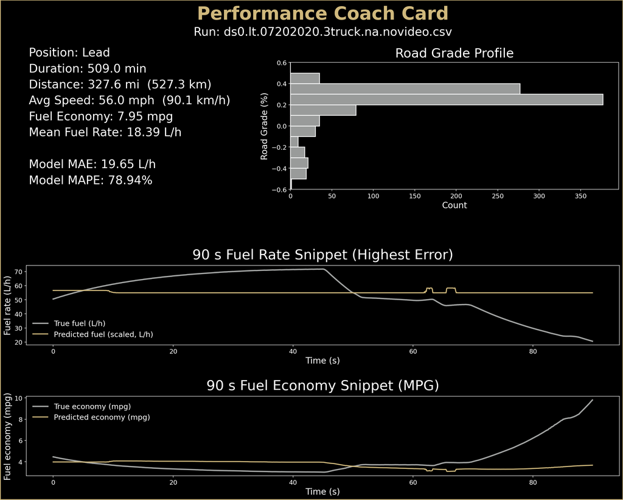

```
[ok  middle] 20250930_213052_coach_card_ds0.mt.07202020.3truck.na.novideo.png
```

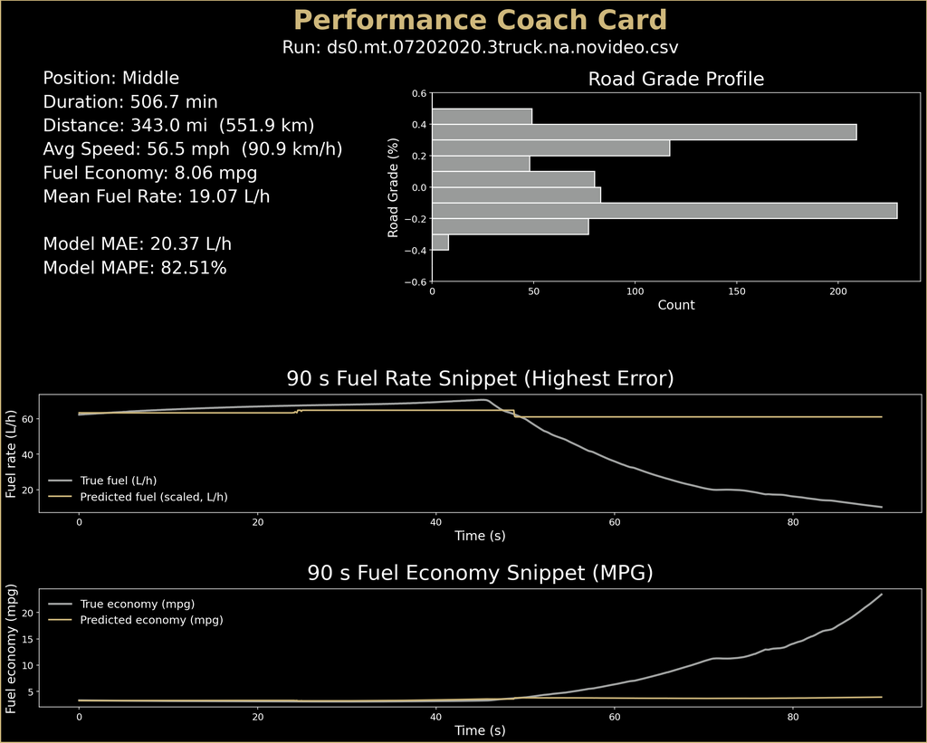

```
[ok  trailing] 20250930_213104_coach_card_ds0.tt.07202020.3truck.na.novideo.png
```

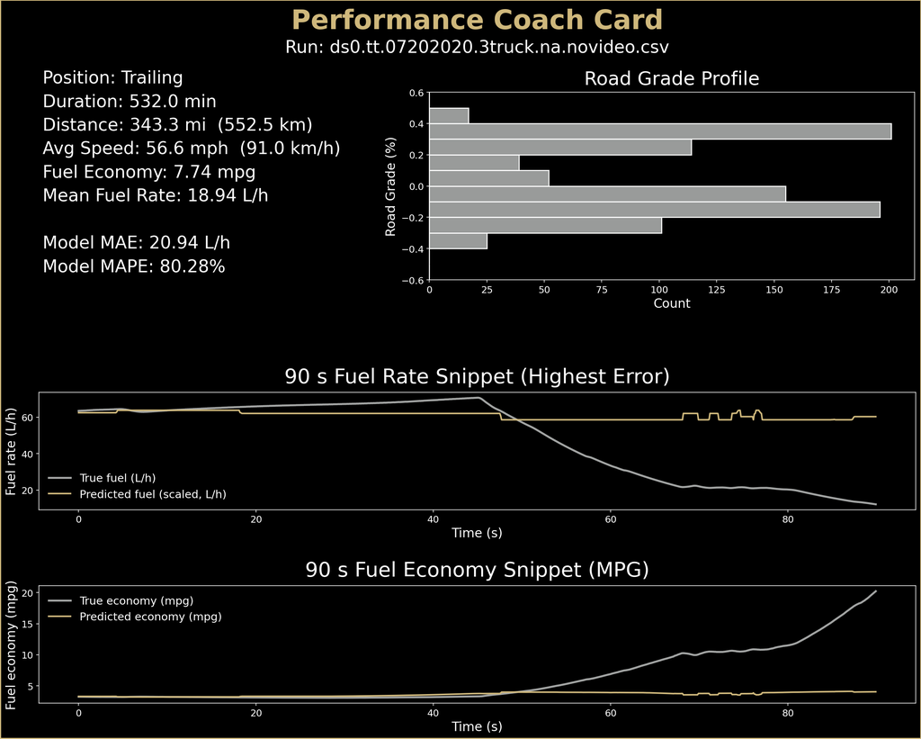

```python
# Create the output directory for the coach cards.
CARDS_DIR.mkdir(parents=True, exist_ok=True)

# Load and preprocess the data for a single truck run.
def _load_card_df(full_path: str) -> pd.DataFrame:
    df = read_selected_csv(full_path, SELECTED_COLUMNS, DTYPES, RENAME_MAP)
    if df.empty:
        return df
    df, _ = unify_timebase(df)
    if "fuel_inst" not in df.columns:
        return pd.DataFrame()
    if "fuel_smooth" not in df.columns:
        df["fuel_smooth"] = df["fuel_inst"].ewm(
            halflife=EWMA_HALF_LIFE * TARGET_HZ, ignore_na=True
        ).mean()
    for col in FINAL_MODEL_FEATURES:
        if col not in df.columns:
            df[col] = 0.0
    if "road_grade_pct" in df.columns:
        q99 = df["road_grade_pct"].abs().quantile(0.99)
        if pd.notna(q99) and q99 < 0.2:
            df["road_grade_pct"] = df["road_grade_pct"] * 100.0
    return df

# Create sliding windows of sequence data for the model.
def _make_windows(df: pd.DataFrame, window_size: int) -> np.ndarray:
    feats = df[FINAL_MODEL_FEATURES].to_numpy(dtype=np.float32)
    if len(df) <= window_size:
        return np.array([])
    X = np.lib.stride_tricks.sliding_window_view(
        feats, (window_size, feats.shape[1])
    )[:, 0]
    return X

# Run inference on a sequence of windows using the trained model.
def _predict_seq(model, X_np, device):
    if X_np.size == 0:
        return np.array([])
    ds = torch.utils.data.TensorDataset(torch.from_numpy(X_np).float())
    ld = torch.utils.data.DataLoader(ds, batch_size=2048, shuffle=False)
    outs = []
    with torch.no_grad():
        for (xb,) in ld:
            xb = xb.to(device)
            with torch.cuda.amp.autocast(enabled=torch.cuda.is_available()):
                y = model(xb)
            outs.append(y.float().cpu().numpy())
    return np.concatenate(outs, axis=0) if outs else np.array([])

# Calculate total distance driven in miles by integrating speed over time.
def _integrate_distance_miles(df: pd.DataFrame) -> float:
    dt_s = df["corrected_time_dt"].diff().dt.total_seconds().fillna(0.0)
    km = (df["CAN_v_speed"] * (dt_s / 3600.0)).sum()
    return km / 1.609344

# Calculate total fuel consumed in gallons by integrating fuel rate over time.
def _integrate_fuel_gallons(df: pd.DataFrame, rate_col: str = "fuel_smooth") -> float:
    dt_s = df["corrected_time_dt"].diff().dt.total_seconds().fillna(0.0)
    liters = (df[rate_col] * (dt_s / 3600.0)).sum()
    return liters / 3.785411784

# Find a scaling factor to align predicted vs. true values for plotting.
def _robust_scale_for_plot(y_true: np.ndarray, y_pred: np.ndarray) -> float:
    m = np.isfinite(y_true) & np.isfinite(y_pred) & (np.abs(y_pred) > 1e-6)
    if not np.any(m):
        return 1.0
    scale = np.median(y_true[m] / y_pred[m])
    return float(np.clip(scale, 0.1, 200.0))

# Generate and save a single performance coach card visualization.
def _make_card(run_df: pd.DataFrame, meta: dict, out_path_png: Path):
    # Create the figure and subplot layout.
    plt.close("all")
    fig = plt.figure(figsize=(20, 16), facecolor="black")
    fig.patch.set_edgecolor("#CFB87C"); fig.patch.set_linewidth(2)
    gs = fig.add_gridspec(4, 2, hspace=0.65, wspace=0.35)
    ax_title = fig.add_subplot(gs[0, :]); ax_title.axis("off")
    ax_kpi   = fig.add_subplot(gs[1, 0]); ax_kpi.axis("off")
    ax_hist  = fig.add_subplot(gs[1, 1])
    ax_lph   = fig.add_subplot(gs[2, :])
    ax_mpg   = fig.add_subplot(gs[3, :])

    # Add the main title and run name.
    ax_title.text(0.5, 0.8, "Performance Coach Card", ha="center",
                  color="#CFB87C", fontsize=34, fontweight="bold")
    ax_title.text(0.5, 0.60, f"Run: {meta['name']}", ha="center",
                  color="white", fontsize=22)

    # Create and place the block of Key Performance Indicators (KPIs).
    mph = meta["avg_speed_mph"]; kmh = meta["avg_speed_kmh"]
    miles = meta["miles"]; km = meta["km"]; mpg = meta["mpg"]
    kpi = (
        f"Position: {meta['position'].capitalize()}\n"
        f"Duration: {meta['duration_min']:.1f} min\n"
        f"Distance: {miles:.1f} mi  ({km:.1f} km)\n"
        f"Avg Speed: {mph:.1f} mph  ({kmh:.1f} km/h)\n"
        f"Fuel Economy: {mpg:.2f} mpg\n"
        f"Mean Fuel Rate: {meta['mean_fuel_Lph']:.2f} L/h\n\n"
        f"Model MAE: {meta['mae_Lph']:.2f} L/h\n"
        f"Model MAPE: {meta['mape_pct']:.2f}%\n"
    )
    ax_kpi.text(0.01, 2.1, kpi, va="top", ha="left", color="white", fontsize=22, linespacing=1.5)

    # Plot the histogram of the road grade profile.
    ax_hist.set_facecolor("black")
    for s in ax_hist.spines.values(): s.set_edgecolor("white")
    grades_pct = run_df["road_grade_pct"].dropna().to_numpy()
    grades_pct = np.clip(grades_pct, -8, 8)
    bins = np.arange(-2.0, 2.0 + 0.1, 0.1)
    ax_hist.hist(grades_pct, bins=bins, color="#A2A4A3", orientation="horizontal", alpha=0.95, edgecolor="white", linewidth=1.4)
    ax_hist.set_title("Road Grade Profile", color="white", fontsize=24, pad=10)
    ax_hist.set_ylabel("Road Grade (%)", color="white", fontsize=16)
    ax_hist.set_xlabel("Count", color="white", fontsize=16)
    ax_hist.tick_params(colors="white", labelsize=12)
    ax_hist.set_ylim(-0.6, 0.6)
    pos = ax_hist.get_position()
    ax_hist.set_position([pos.x0 - 0.10, pos.y0 + 0.04, pos.width * 1.30, pos.height * 1.60])

    # Plot the 90-second fuel rate snippet (L/h).
    t = run_df["time_sec"].to_numpy()
    y_true = run_df["fuel_true"].to_numpy()
    y_pred = run_df["fuel_pred"].to_numpy()
    y_pred_plot = y_pred * _robust_scale_for_plot(y_true, y_pred)
    ax_lph.set_facecolor("black")
    for s in ax_lph.spines.values(): s.set_edgecolor("white")
    ax_lph.plot(t, y_true,      color="#A2A4A3", lw=2.5, label="True fuel (L/h)")
    ax_lph.plot(t, y_pred_plot, color="#CFB87C", lw=2.0, label="Predicted fuel (scaled, L/h)")
    ax_lph.set_title("90 s Fuel Rate Snippet (Highest Error)", color="white", fontsize=26, pad=12)
    ax_lph.set_xlabel("Time (s)", color="white", fontsize=16)
    ax_lph.set_ylabel("Fuel rate (L/h)", color="white", fontsize=16)
    ax_lph.tick_params(colors="white", labelsize=12)
    ax_lph.legend(frameon=False, facecolor="black", labelcolor="white", fontsize=14, loc="best")

    # Plot the 90-second fuel economy snippet (MPG).
    mph_snip = run_df["CAN_v_speed"].to_numpy() / 1.609344
    gph_true = y_true / 3.785411784
    gph_pred = y_pred_plot / 3.785411784
    mpg_true = np.where(gph_true > 1e-6, mph_snip / gph_true, np.nan)
    mpg_pred = np.where(gph_pred > 1e-6, mph_snip / gph_pred, np.nan)
    ax_mpg.set_facecolor("black")
    for s in ax_mpg.spines.values(): s.set_edgecolor("white")
    ax_mpg.plot(t, mpg_true, color="#A2A4A3", lw=2.5, label="True economy (mpg)")
    ax_mpg.plot(t, mpg_pred, color="#CFB87C", lw=2.0, label="Predicted economy (mpg)")
    ax_mpg.set_title("90 s Fuel Economy Snippet (MPG)", color="white", fontsize=26, pad=12)
    ax_mpg.set_xlabel("Time (s)", color="white", fontsize=16)
    ax_mpg.set_ylabel("Fuel economy (mpg)", color="white", fontsize=16)
    ax_mpg.tick_params(colors="white", labelsize=12)
    ax_mpg.legend(frameon=False, facecolor="black", labelcolor="white", fontsize=14, loc="best")

    # Finalize and save the figure.
    plt.tight_layout()
    fig.savefig(out_path_png, dpi=150, bbox_inches="tight")
    plt.close(fig)

# Generate a coach card for each truck position in the selected platoon run.
print("-" * 70); print("--- Generating Coach Cards ---")
cards_made = 0
for position, path_str in tqdm(platoon_run_files.items(), total=len(platoon_run_files), desc="Cards"):
    try:
        df = _load_card_df(path_str)
        if df.empty or len(df) < WINDOW_SIZE:
            print(f"[skip {position}] Not enough valid data rows ({len(df)})")
            continue

        # Generate model predictions for the entire run.
        df["fuel_true"] = df["fuel_smooth"].copy()
        X_seq = _make_windows(df, WINDOW_SIZE)
        if X_seq.size == 0:
            print(f"[skip {position}] No windows could be created.")
            continue
        X_scaled = preprocess_sequential_features(X_seq, numeric_feature_indices, time_scaler)
        preds = _predict_seq(final_model, X_scaled, device)

        # Align predictions with the original dataframe.
        df["fuel_pred"] = np.nan
        start_idx = WINDOW_SIZE - 1
        stop_idx  = start_idx + len(preds)
        pred_align_idx = df.index[start_idx:stop_idx]
        if preds.size and len(pred_align_idx) == len(preds):
            df.loc[pred_align_idx, "fuel_pred"] = preds[:, 1]
        else:
            print(f"[skip {position}] Prediction alignment failed.")
            continue

        # Find the 90-second snippet with the highest absolute error.
        df["abs_error"] = (df["fuel_true"] - df["fuel_pred"]).abs()
        center_iloc = df["abs_error"].idxmax()
        start_iloc = max(0, center_iloc - 450)
        end_iloc = start_iloc + 900
        snippet = df.iloc[start_iloc:end_iloc].copy()
        snippet["time_sec"] = np.arange(len(snippet)) * 0.1

        # Calculate run-level summary metrics.
        miles = _integrate_distance_miles(df)
        gallons = _integrate_fuel_gallons(df, rate_col="fuel_true")
        km = miles * 1.609344
        mph = df.loc[df["CAN_v_speed"] > 1, "CAN_v_speed"].mean() / 1.609344
        kmh = mph * 1.609344
        mpg = miles / gallons if gallons > 0 else float("nan")
        meta = {
            "name": Path(path_str).name,
            "position": position,
            "duration_min": (df["corrected_time_dt"].iloc[-1] - df["corrected_time_dt"].iloc[0]).total_seconds()/60.0,
            "miles": miles, "km": km,
            "avg_speed_mph": mph, "avg_speed_kmh": kmh, "mpg": mpg,
            "mean_fuel_Lph": float(df["fuel_true"].mean()),
            "mae_Lph": float(df["abs_error"].mean()),
            "mape_pct": float(
                (df.loc[df["fuel_true"] > 0.1, "abs_error"] /
                 df.loc[df["fuel_true"] > 0.1, "fuel_true"]).mean() * 100.0
            )
        }

        # Generate and display the card.
        out_png = CARDS_DIR / f"{_timestamp()}_coach_card_{Path(path_str).stem}.png"
        _make_card(snippet, meta, out_png)
        cards_made += 1
        print(f"[ok  {position}] {out_png.name}")
        display(Image(filename=str(out_png)))

    except Exception as e:
        import traceback
        print(f"[error {position}] {e}\n{traceback.format_exc()}")

# Print a final status message.
if cards_made == 0:
    print("\nNo cards were produced. See skip/error messages above for details.")
print("-" * 70)
```

### 10.3 Platoon Efficiency

The predictive model is built, but the real question remains: how much fuel does platooning actually save? To answer that, this section first builds the exact comparison groups needed. The initial code cells sift through the raw data to create date-matched lists of both 2-truck and 3-truck platoon runs. The 3-truck list is used for the analysis in this section, while both lists will be needed for the final summary in section 10.4.

With the 3-truck runs identified, the main analysis synchronizes their data to isolate continuous highway driving segments of 15 minutes or more. This apples-to-apples comparison reveals the true fuel economy (MPG) for each truck position. The process generates three distinct plots and summary tables, breaking down the efficiency benefits across different speed buckets: 70, 85, and 100 km/h.

```python
# --- 10.3a ---

# Build a list of strictly date-matched 2-truck (lead/trailing) run pairs.
assert 'DATA_DIR' in globals(), "DATA_DIR must be defined."

# Define regular expressions to find truck roles in filenames.
ROLE_TOKENS_2 = {
    "lead":     [r"\b(?:lt|lead|leader|head|hd)\b"],
    "trailing": [r"\b(?:tt|tail|trailing|rear|follow|ft|follower)\b"],
}

# Classify the truck's role based on its filename.
def _classify_role_2(name: str) -> str:
    s = re.sub(r"[^a-z0-9]+", " ", name.lower())
    for role, pats in ROLE_TOKENS_2.items():
        for pat in pats:
            if re.search(pat, s):
                return role
    return "unknown"

# Check if the filename indicates a 2-truck run.
def _is_two_truck(name: str) -> bool:
    return bool(re.search(r"\b2truck\b", name.lower()))

# Extract an 8-digit date token from the filename.
def _extract_date_token_2(name: str) -> str:
    m = re.search(r'(?<!\d)(\d{8})(?!\d)', name)
    return m.group(1) if m else ""

# Find all CSV files and group them by date and role.
all_csvs = list(Path(DATA_DIR).rglob("*.csv"))
by_date_role_2 = defaultdict(dict)
for p in all_csvs:
    name = p.name
    if not _is_two_truck(name):
        continue
    role = _classify_role_2(name)
    if role not in ("lead", "trailing"):
        continue
    dtok = _extract_date_token_2(name)
    if not dtok:
        continue
    by_date_role_2[dtok].setdefault(role, str(p))

# Build pairs where both a lead and trailing truck are present for the same date.
pairs_2truck = []
for dtok, roles in sorted(by_date_role_2.items()):
    if {"lead", "trailing"}.issubset(roles.keys()):
        pairs_2truck.append({
            "date": dtok,
            "lead": roles["lead"],
            "trailing": roles["trailing"],
        })

# Flatten the list of pairs into a dictionary suitable for analysis.
platoon_pairs = {
    "lead":     [t["lead"]     for t in pairs_2truck],
    "trailing": [t["trailing"] for t in pairs_2truck],
}

# Print a summary of the date-matched pairs found.
print("-" * 70)
print("--- Found Date-Matched 2-Truck Pairs ---")
print(f"Found {len(pairs_2truck)} total pairs.")
for t in pairs_2truck[:5]:
    print(f"  {t['date']}:")
    print("     LT:", Path(t["lead"]).name)
    print("     TT:", Path(t["trailing"]).name)
if len(pairs_2truck) > 5:
    print("  ...")

# Print the final file counts per role.
print("\n--- Final 2-Truck File Counts ---")
for k in ("lead", "trailing"):
    print(f"  {k:9s} {len(platoon_pairs[k])} files")
print("-" * 70)

# Verify that files for both roles were found.
assert len(platoon_pairs["lead"]) > 0,     "No 2-truck LEAD files found."
assert len(platoon_pairs["trailing"]) > 0, "No 2-truck TRAILING files found."
```

```
Found 21 2-truck pairs (date-matched).
  08172020:
     LT: ds0.lt.08172020.2truck.baseline.novideo.csv
     TT: ds0.tt.08172020.2truck.baseline.novideo.csv
  08192020:
     LT: ds0.lt.08192020.2truck.baseline.novideo.csv
     TT: ds0.tt.08192020.2truck.baseline.novideo.csv
  08202020:
     LT: ds0.lt.08202020.2truck.baseline.novideo.csv
     TT: ds0.tt.08202020.2truck.baseline.novideo.csv
  08212020:
     LT: ds0.lt.08212020.2truck.baseline.novideo.csv
     TT: ds0.tt.08212020.2truck.baseline.novideo.csv
  08242020:
     LT: ds0.lt.08242020.2truck.baseline.novideo.csv
     TT: ds0.tt.08242020.2truck.baseline.novideo.csv
  08262020:
     LT: ds0.lt.08262020.2truck.caccnoadept.novideo.csv
     TT: ds0.tt.08262020.2truck.caccnoadept.completed.csv
  09082020:
     LT: ds0.lt.09082020.2truck.caccadept.novideo.csv
     TT: ds0.tt.09082020.2truck.caccadept.completed.csv
  09092020:
     LT: ds0.lt.09092020.2truck.caccadept.completed.csv
     TT: ds0.tt.09092020.2truck.caccadept.completed.csv
  10052020:
     LT: ds0.lt.10052020.2truck.caccadept.completed.csv
     TT: ds0.tt.10052020.2truck.caccadept.completed.csv
  10072020:
     LT: ds0.lt.10072020.2truck.caccadept.completed.csv
     TT: ds0.tt.10072020.2truck.caccadept.completed.csv
  ...

Strict 2-truck counts (date-matched):
  lead      21 files
  trailing  21 files
```

```python
# --- 10.3b ---

# Build a list of strictly date-matched 3-truck (lead/middle/trailing) run triplets.
assert 'DATA_DIR' in globals(), "DATA_DIR must be defined."

# Define regular expressions to find truck roles in filenames.
ROLE_TOKENS = {
    "lead":     [r"\b(?:lt|lead|leader|head|hd)\b"],
    "middle":   [r"\b(?:mt|mid|middle|m\d?)\b"],
    "trailing": [r"\b(?:tt|tail|trailing|rear|follow)\b"],
}

# Classify the truck's role based on its filename.
def _classify_role(name: str) -> str:
    s = re.sub(r"[^a-z0-9]+", " ", name.lower())
    for role, pats in ROLE_TOKENS.items():
        for pat in pats:
            if re.search(pat, s):
                return role
    return "unknown"

# Check if the filename indicates a 3-truck run.
def _is_three_truck(name: str) -> bool:
    return bool(re.search(r"\b3truck\b", name.lower()))

# Extract an 8-digit date token from the filename.
def _extract_date_token(name: str) -> str:
    m = re.search(r'(?<!\d)(\d{8})(?!\d)', name)
    return m.group(1) if m else ""

# Find all CSV files and group them by date and role.
all_csvs = list(Path(DATA_DIR).rglob("*.csv"))
by_date_role = defaultdict(dict)
for p in all_csvs:
    name = p.name
    if not _is_three_truck(name):
        continue
    role = _classify_role(name)
    if role not in ("lead","middle","trailing"):
        continue
    dtok = _extract_date_token(name)
    if not dtok:
        continue
    by_date_role[dtok].setdefault(role, str(p))

# Build triplets where all three roles are present for the same date.
triplets = []
for dtok, roles in sorted(by_date_role.items()):
    if {"lead","middle","trailing"}.issubset(roles.keys()):
        triplets.append({
            "date": dtok,
            "lead": roles["lead"],
            "middle": roles["middle"],
            "trailing": roles["trailing"],
        })

# Flatten the list of triplets into a dictionary suitable for analysis.
platoon_runs = {
    "lead":     [t["lead"]     for t in triplets],
    "middle":   [t["middle"]   for t in triplets],
    "trailing": [t["trailing"] for t in triplets],
}

# Print a summary of the date-matched triplets found.
print("-" * 70)
print("--- Found Date-Matched 3-Truck Triplets ---")
print(f"Found {len(triplets)} total triplets.")
for t in triplets[:3]:
    print(f"  {t['date']}:")
    print("     LT:", Path(t["lead"]).name)
    print("     MT:", Path(t["middle"]).name)
    print("     TT:", Path(t["trailing"]).name)
if len(triplets) > 3:
    print("  ...")

# Print the final file counts per role.
print("\n--- Final 3-Truck File Counts ---")
for k in ("lead","middle","trailing"):
    print(f"  {k:9s} {len(platoon_runs[k])} files")
print("-" * 70)

# Verify that files for all three roles were found.
assert len(platoon_runs["lead"]) > 0,     "No 3-truck LEAD files found."
assert len(platoon_runs["middle"]) > 0,   "No 3-truck MIDDLE files found."
assert len(platoon_runs["trailing"]) > 0, "No 3-truck TRAILING files found."
```

```
Found 4 3-truck triplets (date-matched).
  07202020:
     LT: ds0.lt.07202020.3truck.na.novideo.csv
     MT: ds0.mt.07202020.3truck.na.novideo.csv
     TT: ds0.tt.07202020.3truck.na.novideo.csv
  07212020:
     LT: ds0.lt.07212020.3truck.na.novideo.csv
     MT: ds0.mt.07212020.3truck.na.novideo.csv
     TT: ds0.tt.07212020.3truck.na.novideo.csv
  07222020:
     LT: ds0.lt.07222020.3truck.na.novideo.csv
     MT: ds0.mt.07222020.3truck.na.novideo.csv
     TT: ds0.tt.07222020.3truck.na.novideo.csv
  07232020:
     LT: ds0.lt.07232020.3truck.na.novideo.csv
     MT: ds0.mt.07232020.3truck.na.novideo.csv
     TT: ds0.tt.07232020.3truck.na.novideo.csv

Strict 3-truck counts (date-matched):
  lead      4 files
  middle    4 files
  trailing  4 files
```

```
----------------------------------------------------------------------
Platoon efficiency (highway ≥ 70 km/h, segments ≥ 15 min)
Triplets contributing: 4 / 4
```

| Role | Fuel Economy (mpg) | Distance (mi) | Fuel Used (gal) | Avg Speed (mph) | Avg Grade (%) |
| --- | --- | --- | --- | --- | --- |
| Lead | 7.50 | 1366.31 | 182.22 | 62.11 | 0.00 |
| Middle | 6.81 | 1385.13 | 203.45 | 62.06 | 0.00 |
| Trailing | 7.46 | 1362.69 | 182.70 | 62.27 | 0.00 |

```
Figure saved to: /home/treinart/projects/ADAS_fuel_rate/artifacts/figures/20251002_203507_platoon_mpg_overlap_70kmh_multi.png
```

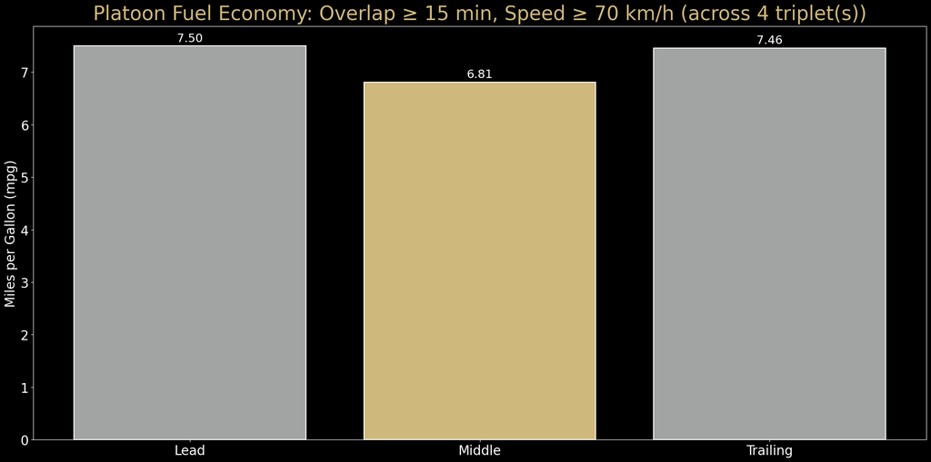

```
----------------------------------------------------------------------
Platoon efficiency (highway ≥ 85 km/h, segments ≥ 15 min)
Triplets contributing: 4 / 4
```

| Role | Fuel Economy (mpg) | Distance (mi) | Fuel Used (gal) | Avg Speed (mph) | Avg Grade (%) |
| --- | --- | --- | --- | --- | --- |
| Lead | 7.62 | 1177.04 | 154.49 | 62.16 | 0.00 |
| Middle | 6.93 | 1194.65 | 172.28 | 62.11 | 0.00 |
| Trailing | 7.84 | 1172.94 | 149.63 | 62.32 | 0.00 |

```
Figure saved to: /home/treinart/projects/ADAS_fuel_rate/artifacts/figures/20251002_203522_platoon_mpg_overlap_85kmh_multi.png
```

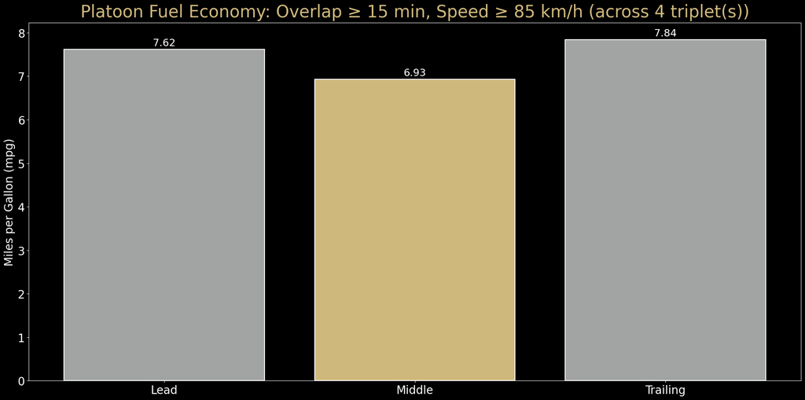

```
----------------------------------------------------------------------
Platoon efficiency (highway ≥ 100 km/h, segments ≥ 15 min)
Triplets contributing: 4 / 4
```

| Role | Fuel Economy (mpg) | Distance (mi) | Fuel Used (gal) | Avg Speed (mph) | Avg Grade (%) |
| --- | --- | --- | --- | --- | --- |
| Lead | 8.96 | 739.74 | 82.54 | 63.99 | -0.02 |
| Middle | 7.24 | 757.61 | 104.71 | 64.45 | -0.03 |
| Trailing | 7.26 | 744.47 | 102.61 | 65.43 | -0.05 |

```
Figure saved to: /home/treinart/projects/ADAS_fuel_rate/artifacts/figures/20251002_203535_platoon_mpg_overlap_100kmh_multi.png
```

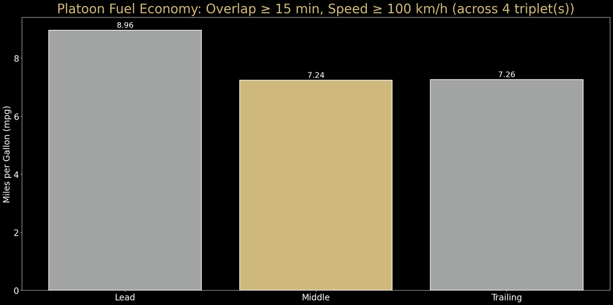

```python
# --- 10.3c ---

# Define constants and configuration for the efficiency analysis.
SMOOTH_COL       = "fuel_smooth"
STATUS_CANDS     = ["HMI_CACC_Status", "HMI_V2V_Status"]
GRADE_CANDS      = ["road_grade_pct", "roadGrade"]
MIN_SEG_MIN      = 15.0
MAX_GAP_SEC      = 1.0
SPEED_THRESHOLDS = [70.0, 85.0, 100.0]
SOLO_BASELINE_MPG = 6.8
assert "triplets" in globals() and len(triplets) > 0, "Run the triplet builder first."

# Find the first available column in a dataframe from a list of candidates.
def _pick_col(df, candidates):
    for c in candidates:
        if c in df.columns:
            return c
    return ""

# Load, clean, and standardize data for a single run.
def _load_run(full_path: str):
    df = read_selected_csv(full_path, SELECTED_COLUMNS, DTYPES, RENAME_MAP)
    if df.empty: return pd.DataFrame(), ""
    df, _ = unify_timebase(df)
    for c in ["corrected_time_dt", "CAN_v_speed"]:
        if c not in df.columns: raise AssertionError(f"Missing required column: {c}")
    if SMOOTH_COL not in df.columns:
        if "fuel_inst" not in df.columns: raise AssertionError("Need 'fuel_inst' to compute smoothed fuel.")
        df[SMOOTH_COL] = df["fuel_inst"].ewm(halflife=EWMA_HALF_LIFE * TARGET_HZ, ignore_na=True).mean()
    gcol = _pick_col(df, GRADE_CANDS)
    if not gcol: raise AssertionError(f"No road-grade column found. Tried {GRADE_CANDS}.")
    q99 = df[gcol].abs().quantile(0.99)
    if pd.notna(q99) and q99 < 0.2: df[gcol] = df[gcol] * 100.0
    df = df.rename(columns={gcol: "road_grade_pct"})
    scol = _pick_col(df, STATUS_CANDS)
    return df, scol

# Filter a dataframe for highway speeds and active CACC status.
def _filter_highway_and_status(df: pd.DataFrame, speed_min_kmh: float, status_col: str):
    if status_col:
        active = (df[status_col].fillna(0).astype(float) == 1.0)
    else:
        active = pd.Series(True, index=df.index)
    m = active & (df["CAN_v_speed"] >= speed_min_kmh)
    return df.loc[m, ["corrected_time_dt", "CAN_v_speed", "road_grade_pct", SMOOTH_COL]].copy()

# Perform an inner join on three dataframes using an exact timestamp match.
def _join_on_time(d_lead, d_mid, d_tail):
    j = (d_lead.merge(d_mid, on="corrected_time_dt", suffixes=("_lead","_mid"), how="inner")
               .merge(d_tail, on="corrected_time_dt", how="inner"))
    j = j.rename(columns={
        "CAN_v_speed": "CAN_v_speed_tail", "road_grade_pct": "road_grade_pct_tail",
        SMOOTH_COL: f"{SMOOTH_COL}_tail",
    }).sort_values("corrected_time_dt").reset_index(drop=True)
    j["dt_sec"] = j["corrected_time_dt"].diff().dt.total_seconds().fillna(0.0)
    return j

# Keep only continuous data segments that meet a minimum duration.
def _keep_long_segments(dfJ: pd.DataFrame, min_minutes: float):
    if dfJ.empty: return dfJ
    seg_id = (dfJ["dt_sec"] > MAX_GAP_SEC).cumsum()
    dfJ = dfJ.assign(_seg=seg_id)
    seg_dur = dfJ.groupby("_seg")["dt_sec"].sum()
    keep_ids = seg_dur[seg_dur >= (min_minutes*60)].index
    return dfJ[dfJ["_seg"].isin(keep_ids)].drop(columns=["_seg"]).copy()

# Calculate total miles, gallons, MPG, and other stats for a single truck role.
def _totals_for_role(dfJ: pd.DataFrame, role: str) -> dict:
    v_kmh = dfJ[f"CAN_v_speed_{role}"]; dt_h = dfJ["dt_sec"]/3600.0
    km = (v_kmh * dt_h).sum(); miles = km / 1.609344
    liters = (dfJ[f"{SMOOTH_COL}_{role}"] * dt_h).sum(); gallons = liters / 3.785411784
    mph = (v_kmh.mean() / 1.609344) if len(v_kmh) else float("nan")
    grade = dfJ.get(f"road_grade_pct_{role}", pd.Series(np.nan)).mean()
    mpg = (miles / gallons) if gallons > 0 else float("nan")
    return dict(miles=miles, gallons=gallons, mpg=mpg, mph=mph, grade_pct=grade)

# Aggregate results from multiple runs by summing distance and fuel.
def _agg_sum(rows: list[dict]) -> dict:
    if not rows: return dict(miles=0.0, gallons=0.0, mpg=np.nan, mph=np.nan, grade_pct=np.nan)
    miles = sum(r["miles"] for r in rows)
    gallons = sum(r["gallons"] for r in rows)
    mpg = (miles / gallons) if gallons > 0 else float("nan")
    mph = np.average([r["mph"] for r in rows], weights=[max(r["miles"],1e-6) for r in rows])
    grade = np.mean([r["grade_pct"] for r in rows])
    return dict(miles=miles, gallons=gallons, mpg=mpg, mph=mph, grade_pct=grade)

# Run the full analysis pipeline for a single speed bucket.
def _run_bucket_across_triplets(speed_min_kmh: float):
    print("-" * 70)
    print(f"--- Platoon Efficiency | Speed >= {speed_min_kmh:.0f} km/h, Segments >= {MIN_SEG_MIN:.0f} min ---")
    res_lead, res_mid, res_tail = [], [], []

    # Process each triplet to find valid, overlapping highway segments.
    for t in triplets:
        d_lead, st_lead = _load_run(t["lead"])
        d_mid,  st_mid  = _load_run(t["middle"])
        d_tail, st_tail = _load_run(t["trailing"])
        f_lead = _filter_highway_and_status(d_lead, speed_min_kmh, st_lead)
        f_mid  = _filter_highway_and_status(d_mid,  speed_min_kmh, st_mid)
        f_tail = _filter_highway_and_status(d_tail, speed_min_kmh, st_tail)
        f_lead = f_lead.rename(columns={c: f"{c}_lead" for c in f_lead.columns if c != "corrected_time_dt"})
        f_mid  = f_mid.rename(columns={c: f"{c}_mid" for c in f_mid.columns if c != "corrected_time_dt"})
        j_all = _join_on_time(f_lead, f_mid, f_tail)
        if j_all.empty: continue
        j = _keep_long_segments(j_all, MIN_SEG_MIN)
        if j.empty or j["dt_sec"].sum() <= 0: continue
        res_lead.append(_totals_for_role(j, "lead"))
        res_mid.append(_totals_for_role(j, "mid"))
        res_tail.append(_totals_for_role(j, "tail"))

    if not res_lead:
        print("No adequate common highway segments were found for this speed bucket.")
        return

    # Aggregate the results and create a summary table.
    agg_lead = _agg_sum(res_lead)
    agg_mid  = _agg_sum(res_mid)
    agg_tail = _agg_sum(res_tail)
    tbl = pd.DataFrame([
        dict(Role="Lead", **agg_lead), dict(Role="Middle", **agg_mid), dict(Role="Trailing", **agg_tail),
    ])
    tbl = tbl.rename(columns={
        "mpg": "Fuel Economy (mpg)", "miles": "Distance (mi)", "gallons": "Fuel Used (gal)",
        "mph": "Avg Speed (mph)", "grade_pct": "Avg Grade (%)",
    })[["Role", "Fuel Economy (mpg)", "Distance (mi)", "Fuel Used (gal)", "Avg Speed (mph)", "Avg Grade (%)"]]
    print(f"Triplets contributing to this result: {len(res_lead)} / {len(triplets)}")
    num_cols = [c for c in tbl.columns if c != "Role"]
    display(cubuff_style_table(tbl).format({c: "{:.2f}" for c in num_cols}))

    if speed_min_kmh >= 99.5:
        global tbl_100
        tbl_100 = tbl.copy()

    # Create the figure and axes.
    plt.close("all")
    fig, ax = plt.subplots(figsize=(20, 10), facecolor="black")
    ax.set_facecolor("black")

    # Plot the bar chart.
    bars = ax.bar(tbl["Role"], tbl["Fuel Economy (mpg)"],
                  color=["#A2A4A3", "#CFB87C", "#A2A4A3"], edgecolor="white", linewidth=1.5)

    # Set titles and labels.
    ax.set_title(
        f"Platoon Fuel Economy: Overlap ≥ {int(MIN_SEG_MIN)} min, Speed ≥ {int(speed_min_kmh)} km/h (across {len(res_lead)} triplets)",
        color="#CFB87C", fontsize=30, pad=10)
    ax.set_ylabel("Miles per Gallon (mpg)", color="white", fontsize=20)
    ax.tick_params(colors="white", labelsize=20)

    # Style the plot's border (spines).
    for sp in ax.spines.values(): sp.set_edgecolor("white")

    # Add data labels to the bars.
    ax.bar_label(bars, fmt="%.2f", color="white", fontsize=18, padding=3)

    # Ensure the layout is tight and clean, then save and display.
    plt.tight_layout()
    save_fig(fig, f"platoon_mpg_overlap_{int(speed_min_kmh)}kmh_multi")
    plt.show()

# Execute the analysis for each defined speed threshold.
for kmh in SPEED_THRESHOLDS:
    _run_bucket_across_triplets(kmh)
print("-" * 70)
```

### 10.4 Platoon Savings Comparison

This visualization provides the project's bottom-line results. To create the final comparison, this cell first calculates the measured savings for the 2-truck platoon runs. It then pulls the 3-truck results generated in the previous section 10.3. With all the measured data assembled, the final bar chart puts the findings for both platoon types side-by-side with the conservative estimates from NREL literature. This offers a direct scorecard, comparing this project's findings against the established industry benchmark.

```
2-truck contributing pairs: 8 / 21
```

| Role | Fuel Economy (mpg) | Distance (mi) | Fuel Used (gal) | Avg Speed (mph) | Avg Grade (%) |
| --- | --- | --- | --- | --- | --- |
| Lead | 6.52 | 1249.76 | 191.70 | 64.33 | -0.03 |
| Trailing | 8.61 | 1296.47 | 150.64 | 64.57 | -0.04 |

```
3-truck summary (from ≥100 km/h bucket):
```

| Role | Fuel Economy (mpg) | Distance (mi) | Fuel Used (gal) | Avg Speed (mph) | Avg Grade (%) |
| --- | --- | --- | --- | --- | --- |
| Lead | 8.96 | 739.74 | 82.54 | 63.99 | -0.02 |
| Middle | 7.24 | 757.61 | 104.71 | 64.45 | -0.03 |
| Trailing | 7.26 | 744.47 | 102.61 | 65.43 | -0.05 |

```
Model (2-truck) team-average savings vs solo: 8.3%   (baseline SOLO_BASELINE_MPG = 6.80)
Figure saved to: /home/treinart/projects/ADAS_fuel_rate/artifacts/figures/20251002_203724_platoon_savings_2truck_and_3truck_100kmh.png
```

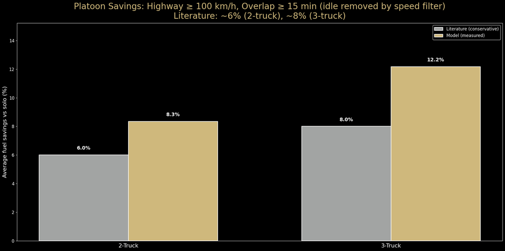

```
----------------------------------------------------------------------
--- Summary (≥100 km/h, ≥15 min overlap; idle removed by speed filter) ---
Literature (conservative): 2-truck = 6.0%, 3-truck = 8.0%
Model (measured): 2-truck = 8.3%   (baseline SOLO_BASELINE_MPG = 6.80)
Model (measured): 3-truck = 12.2%   (from `tbl_100`)
Roles averaged with equal weight per team type.
----------------------------------------------------------------------
```

```python
# Define constants and configuration for the 2-truck analysis.
assert "pairs_2truck" in globals() and len(pairs_2truck) > 0, "Build `pairs_2truck` first."
SMOOTH_COL   = "fuel_smooth"
MIN_SEG_MIN  = 15.0
MAX_GAP_SEC  = 1.0
SPEED_MIN    = 100.0
STATUS_CANDS = ["HMI_CACC_Status", "HMI_V2V_Status"]
GRADE_CANDS  = ["road_grade_pct", "roadGrade"]

# Define a helper function to style pandas DataFrames for display.
def style_dark_gold_2dp(df):
    styles = [
        {"selector": "th", "props": [("background-color", "#565A5C"), ("color", "white"),
                                     ("text-align", "left"), ("border", "1px solid #CFB87C")]},
        {"selector": "td", "props": [("border", "1px solid #CFB87C")]},
        {"selector": "tbody td", "props": [("background-color", "#000000"), ("color", "#F8F8F8"),
                                           ("border-color", "#CFB87C")]},
    ]
    num_cols = [c for c in df.columns if c != "Role"]
    return (df.style.set_table_styles(styles).hide(axis="index")
            .format({c: "{:.2f}" for c in num_cols}))

# Find the first available column from a list of candidates.
def _pick_col_2(df, candidates):
    for c in candidates:
        if c in df.columns: return c
    return ""

# Load, clean, and standardize data for a single run.
def _load_run_2(full_path: str):
    df = read_selected_csv(full_path, SELECTED_COLUMNS, DTYPES, RENAME_MAP)
    if df.empty: return pd.DataFrame(), ""
    df, _ = unify_timebase(df)
    for c in ["corrected_time_dt", "CAN_v_speed"]:
        if c not in df.columns: raise AssertionError(f"Missing required column: {c}")
    if SMOOTH_COL not in df.columns:
        if "fuel_inst" not in df.columns: raise AssertionError("Need 'fuel_inst' to compute smoothed fuel.")
        df[SMOOTH_COL] = df["fuel_inst"].ewm(halflife=EWMA_HALF_LIFE * TARGET_HZ, ignore_na=True).mean()
    gcol = _pick_col_2(df, GRADE_CANDS)
    if not gcol: raise AssertionError(f"No road-grade column found. Tried {GRADE_CANDS}.")
    q99 = df[gcol].abs().quantile(0.99)
    if pd.notna(q99) and q99 < 0.2: df[gcol] = df[gcol] * 100.0
    df = df.rename(columns={gcol: "road_grade_pct"})
    scol = _pick_col_2(df, STATUS_CANDS)
    return df, scol

# Filter a dataframe for highway speeds and active CACC status.
def _filter_highway_2(df: pd.DataFrame, speed_min_kmh: float, status_col: str):
    if status_col:
        active = (df[status_col].fillna(0).astype(float) == 1.0)
    else:
        active = pd.Series(True, index=df.index)
    m = active & (df["CAN_v_speed"] >= speed_min_kmh)
    return df.loc[m, ["corrected_time_dt", "CAN_v_speed", "road_grade_pct", SMOOTH_COL]].copy()

# Perform an inner join on two dataframes using an exact timestamp match.
def _join_on_time_2(d_lead, d_tail):
    j = d_lead.merge(d_tail, on="corrected_time_dt", suffixes=("_lead", "_tail"), how="inner")
    j = j.sort_values("corrected_time_dt").reset_index(drop=True)
    j["dt_sec"] = j["corrected_time_dt"].diff().dt.total_seconds().fillna(0.0)
    return j

# Keep only continuous data segments that meet a minimum duration.
def _keep_long_segments_2(dfJ: pd.DataFrame, min_minutes: float):
    if dfJ.empty: return dfJ
    seg_id = (dfJ["dt_sec"] > MAX_GAP_SEC).cumsum()
    dfJ = dfJ.assign(_seg=seg_id)
    seg_dur = dfJ.groupby("_seg")["dt_sec"].sum()
    keep_ids = seg_dur[seg_dur >= (min_minutes * 60.0)].index
    return dfJ[dfJ["_seg"].isin(keep_ids)].drop(columns=["_seg"]).copy()

# Calculate total miles, gallons, and MPG for a single truck role.
def _totals_for_role_2(dfJ: pd.DataFrame, suffix: str) -> dict:
    v_kmh = dfJ[f"CAN_v_speed_{suffix}"]
    dt_h  = dfJ["dt_sec"] / 3600.0
    km    = (v_kmh * dt_h).sum()
    miles = km / 1.609344
    liters = (dfJ[f"{SMOOTH_COL}_{suffix}"] * dt_h).sum()
    gallons = liters / 3.785411784
    mph   = (v_kmh.mean() / 1.609344) if len(v_kmh) else float("nan")
    grade = dfJ.get(f"road_grade_pct_{suffix}", pd.Series(np.nan)).mean()
    mpg   = (miles / gallons) if gallons > 0 else float("nan")
    return dict(miles=miles, gallons=gallons, mpg=mpg, mph=mph, grade_pct=grade)

# Aggregate results from multiple runs by summing distance and fuel.
def _agg_sum_2(rows: list[dict]) -> dict:
    if not rows: return dict(miles=0.0, gallons=0.0, mpg=np.nan, mph=np.nan, grade_pct=np.nan)
    miles   = sum(r["miles"] for r in rows)
    gallons = sum(r["gallons"] for r in rows)
    mpg     = (miles / gallons) if gallons > 0 else float("nan")
    mph     = np.average([r["mph"] for r in rows], weights=[max(r["miles"], 1e-6) for r in rows])
    grade   = np.mean([r["grade_pct"] for r in rows])
    return dict(miles=miles, gallons=gallons, mpg=mpg, mph=mph, grade_pct=grade)

# Process all 2-truck pairs to find valid, overlapping highway segments.
res_lead, res_tail = [], []
for t in pairs_2truck:
    d_lead, st_lead = _load_run_2(t["lead"])
    d_tail, st_tail = _load_run_2(t["trailing"])
    f_lead = _filter_highway_2(d_lead, SPEED_MIN, st_lead).rename(columns={c: f"{c}_lead" for c in ["CAN_v_speed", "road_grade_pct", SMOOTH_COL]})
    f_tail = _filter_highway_2(d_tail, SPEED_MIN, st_tail).rename(columns={c: f"{c}_tail" for c in ["CAN_v_speed", "road_grade_pct", SMOOTH_COL]})
    j_all = _join_on_time_2(f_lead, f_tail)
    if j_all.empty: continue
    j = _keep_long_segments_2(j_all, MIN_SEG_MIN)
    if j.empty or j["dt_sec"].sum() <= 0: continue
    res_lead.append(_totals_for_role_2(j, "lead"))
    res_tail.append(_totals_for_role_2(j, "tail"))

if not res_lead:
    raise RuntimeError("No adequate common highway segments for 2-truck at >=100 km/h.")

# Aggregate the results and create the 2-truck summary table.
agg_lead = _agg_sum_2(res_lead)
agg_tail = _agg_sum_2(res_tail)
tbl2 = pd.DataFrame([
    dict(Role="Lead", **agg_lead), dict(Role="Trailing", **agg_tail),
]).rename(columns={
    "mpg": "Fuel Economy (mpg)", "miles": "Distance (mi)", "gallons": "Fuel Used (gal)",
    "mph": "Avg Speed (mph)", "grade_pct": "Avg Grade (%)",
})[["Role", "Fuel Economy (mpg)", "Distance (mi)", "Fuel Used (gal)", "Avg Speed (mph)", "Avg Grade (%)"]]
print(f"2-truck contributing pairs: {len(res_lead)} / {len(pairs_2truck)}")
display(style_dark_gold_2dp(tbl2))

# If available, display the 3-truck results from the previous section.
if "tbl_100" in globals() and not tbl_100.empty:
    cols_order = ["Role", "Fuel Economy (mpg)", "Distance (mi)", "Fuel Used (gal)", "Avg Speed (mph)", "Avg Grade (%)"]
    tbl3 = tbl_100.set_index("Role").reindex(["Lead", "Middle", "Trailing"]).reset_index()[cols_order].copy()
    print("\n3-truck summary (from >=100 km/h bucket):")
    display(style_dark_gold_2dp(tbl3))

# Calculate the model's measured savings vs. the solo baseline.
solo = float(SOLO_BASELINE_MPG)
role_mpg_2 = tbl2.set_index("Role")["Fuel Economy (mpg)"].reindex(["Lead", "Trailing"])
assert not role_mpg_2.isna().any(), "Two-truck table is missing one or more roles."
per_truck_savings_2 = 1.0 - (solo / role_mpg_2.values)
model_two_truck_team_avg = float(np.nanmean(per_truck_savings_2)) * 100.0

# Pull 3-truck model results if they exist.
try:
    role_mpg_3 = tbl_100.set_index("Role")["Fuel Economy (mpg)"].reindex(["Lead", "Middle", "Trailing"])
    assert not role_mpg_3.isna().any()
    mod_three = float(np.nanmean(1.0 - (solo / role_mpg_3.values))) * 100.0
except Exception:
    mod_three = np.nan
mod_two = model_two_truck_team_avg

# Set up data for the comparison plot.
LIT_SAVINGS = {"two_truck": 0.06, "three_truck": 0.08}
lit_two   = LIT_SAVINGS["two_truck"] * 100.0
lit_three = LIT_SAVINGS["three_truck"] * 100.0
labels = ["2-Truck", "3-Truck"]
x = np.arange(len(labels))
w = 0.34

# Create the figure and axes.
fig, ax = plt.subplots(figsize=(20, 10), facecolor="black")
ax.set_facecolor("black")

# Plot the bars for literature and model-measured savings.
bars_lit = ax.bar(x - w/2, [lit_two, lit_three], width=w, color="#A2A4A3",
                  edgecolor="white", linewidth=1.5, label="Literature (conservative)")
bars_mod = ax.bar(x + w/2, [mod_two, 0.0 if np.isnan(mod_three) else mod_three], width=w,
                  color="#CFB87C", edgecolor="white", linewidth=1.5, label="Model (measured)")

# Define a helper to annotate the bars with their values.
def _annotate(ax, bar, val):
    h = bar.get_height()
    if np.isnan(val):
        ax.text(bar.get_x() + bar.get_width() / 2, 0.2, "N/A", ha="center", va="bottom",
                color="white", fontsize=14, fontweight="bold")
    else:
        ax.text(bar.get_x() + bar.get_width() / 2, h + 0.3, f"{val:.1f}%", ha="center",
                va="bottom", color="white", fontsize=14, fontweight="bold")

# Add the annotations to each bar.
for b, v in zip(bars_lit, [lit_two, lit_three]): _annotate(ax, b, v)
for b, v in zip(bars_mod, [mod_two, mod_three]): _annotate(ax, b, v)

# Set the titles and labels.
ax.set_xticks(x, labels, color="white", fontsize=16)
ax.set_ylabel("Average fuel savings vs solo (%)", color="white", fontsize=16)
ax.set_title(
    "Platoon Savings: Highway ≥ 100 km/h, Overlap ≥ 15 min\n"
    "Literature: ~6% (2-truck), ~8% (3-truck)",
    color="#CFB87C", fontsize=24, pad=12)
ax.tick_params(axis="y", colors="white", labelsize=12)

# Style the plot's border and legend.
for spine in ax.spines.values(): spine.set_edgecolor("white")
ax.legend(facecolor="black", edgecolor="white", labelcolor="white", fontsize=12)
ax.set_ylim(0, max(lit_three, np.nan_to_num(mod_three, nan=0.0), mod_two) * 1.25)

# Ensure a clean layout, save the figure, and display the plot.
plt.tight_layout()
save_fig(fig, "platoon_savings_2truck_and_3truck_100kmh")
plt.show()

# Print the final summary text.
print("-" * 70)
print("--- Summary (≥100 km/h, ≥15 min overlap) ---")
print(f"Literature (conservative): 2-truck = {lit_two:.1f}%, 3-truck = {lit_three:.1f}%")
print(f"Model (measured): 2-truck = {mod_two:.1f}% (vs. baseline of {solo:.2f} MPG)")
if np.isnan(mod_three):
    print("Model (measured): 3-truck = N/A (results not available)")
else:
    print(f"Model (measured): 3-truck = {mod_three:.1f}% (from 10.3c results)")
print("-" * 70)
```

### 10.5 Interactive ROI Calculator

The final deliverable is an interactive tool designed for a fleet manager. To make it more accessible, the calculator was built as a standalone web application, available at the link below. The tool allows a user to input their own fleet's operational parameters, such as annual mileage and fuel price, to generate a real-time estimate of their potential annual savings. This transforms the static findings of this analysis into a practical tool for real-world decision making.

[Truck Platooning: Interactive ROI Calculator](https://treinart.github.io/CSCA-5642-Introduction-to-Deep-Learning/Truck_Platooning_ROI_Calculator_v9.html)

## Section 11: Conclusion & Final Analysis

This project was a story of adapting to reality. The initial plan centered on high-impact visuals like a synchronized "Platoon Theater" video and a "Fuel Surface Map." That plan failed. The theater proved to be a low-value gimmick. The surface map worked once, then threw errors I couldn't work around. I wasn't willing to rerun any training cells to fix it, so I pivoted.

### The Discovery in the Data

That pivot became the project's defining moment. The first analysis of platoon fuel economy produced disappointingly low MPG numbers. The initial fix was to filter out idling time, which helped, but the results were still not compelling. The issue, it turned out, was twofold: the analysis was averaging all speeds together, and it wasn't enforcing a strict requirement for how much the trucks' telemetry had to overlap.

This led to a new approach. By focusing exclusively on long, continuous segments of synchronized highway driving, the true signal began to emerge. The final "aha!" moment came from segmenting the analysis by speed. Displaying the results in three distinct buckets (70, 85, and 100 km/h) made it clear: the significant fuel-saving benefits of platooning are a high-speed phenomenon.

### Final Performance Summary

The entire analysis funnels down to one final result. By isolating the **8 valid 2-truck pairs** and **4 valid 3-truck triplets** during sustained highway driving (at least 100 km/h or ~62 mph), the model's findings could be directly compared to established literature. The results not only validate the core premise but show performance that meets or exceeds conservative industry benchmarks.

| Platoon Size | Team Avg. MPG (Measured) | Solo Baseline MPG | Savings % (Measured) | Savings % (Literature) |
| --- | --- | --- | --- | --- |
| **2-Truck** | 7.42 | 6.80 | **8.3%** | ~6.0% |
| **3-Truck** | 7.74 | 6.80 | **12.2%** | ~8.0% |

### A Surprising Result

One of the most unexpected findings from the 3-truck platoon analysis was the significant fuel economy of the lead truck (8.96 MPG at ≥100 km/h), which outperformed the trailing vehicle. This contradicts most of the published research on the topic. It is unclear if this is new evidence uncovered by the model or simply an anomaly in this specific dataset from a novice at deep learning. A definitive answer would require further study.

### Breaking Down the Savings Calculation

The easiest way to see the difference is to calculate the fuel needed for a fixed 100-mile trip.

$$ \text{Solo Truck (6.8 MPG): Needs } 100 \div 6.80 = 14.71 \text{ gallons.} $$ $$ \text{Platoon Truck (7.74 MPG): Needs } 100 \div 7.74 = 12.92 \text{ gallons.} $$

The platoon truck used **1.79 fewer gallons** to travel the same distance. The percent fuel savings is based on that reduction in consumption.

#### Fuel Savings Calculation

The formula calculates the percentage reduction in fuel consumed.

$$ \text{Fuel Savings %} = \left( 1 - \frac{\text{MPG}_{\text{Solo}}}{\text{MPG}_{\text{Platoon}}} \right) \times 100 $$ $$ \left( 1 - \frac{6.80}{7.74} \right) \times 100 = (1 - 0.87855) \times 100 = \mathbf{12.15\%} \approx 12.2\% $$

#### MPG Increase Calculation

This shows the percent increase in MPG, which is a different metric than fuel savings.

$$ \text{MPG Increase %} = \left( \frac{\text{MPG}_{\text{Platoon}} - \text{MPG}_{\text{Solo}}}{\text{MPG}_{\text{Solo}}} \right) \times 100 $$

$$ \left( \frac{7.74 - 6.80}{6.80} \right) \times 100 = \left( \frac{0.94}{6.80} \right) \times 100 = \mathbf{13.82\%} $$

### What Moved the Needle: Key Learnings & Takeaways

- **A Strong Baseline is Non-Negotiable:** The XGBoost model in Section 7 was more than just a preliminary step. It proved that a classical model could achieve strong results, setting a high bar and forcing the deep learning model to justify its complexity. Its feature importance results also provided the first clear look at the key drivers of fuel use.
- **Sequence Matters:** The performance jump from the XGBoost model to the final CNN-GRU model confirmed the core hypothesis. The deep learning model's ability to understand the sequence of events, not just instantaneous values, was critical for accurately predicting fuel consumption.
- **Pivoting to Practical Tools:** The failure of the initial visualization ideas was a blessing in disguise. It forced a pivot to tools with real-world utility. The **Coach Cards** provide a template for driver-specific feedback, and the final **ROI Calculator** transforms the entire analysis into a financial decision-making tool.

### The ROI Calculator: A Tool for Decision Makers

The original plan was to build an interactive widget in the notebook, but the styling options were poor, the layout was clunky, and it didn't feel like a strong way to wrap up this project. Then I remembered I had built a fuel-savings calculator a few months ago to show customers the advantages of having an APU compared to idling their trucks. I realized I could easily adapt that for measuring platoon savings.

Putting a tool like that in the hands of a fleet owner or manager is powerful. It takes the sales pressure out of the equation - they plug in their own numbers and see the potential for themselves. What's eye-opening is the scale. For a medium-sized fleet of 500 trucks, the ITS site reported from an NREL study that 55.7% of all miles could be platooned. I made a conservative estimate of 35% in 2-truck platoon and 20% in 3-truck platoon. At 120,000 miles per year, 500 trucks, $4 per gallon diesel, and using the fuel savings percentages from this notebook, that translates to roughly **$1.89 million in annual savings**. For a publicly traded mega-fleet with 15,000 trucks, that number jumps to over **$56 million per year** while cutting CO2 emissions by over 300 million pounds. Someone should tell their shareholders.

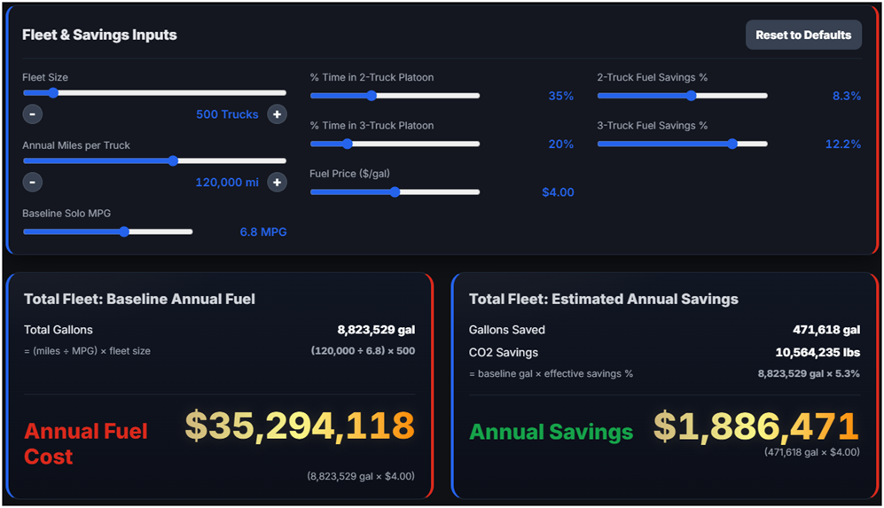

### Future Improvements & Project Reflections

- **Don't Be So Ambitious:** I should have thought more carefully about this project given the data size. It was very time-consuming. I could have found a smaller dataset to work with, but overall I'm happy with the outcomes.
- **Hardware is a Hard Limit:** Having the correct machine or using an online GPU/TPU service like AWS or Google Cloud would have made a huge difference. The limitations of my laptop really held back the project and ultimately are why Optuna didn't have the desired results.
- **Plan at the Cell Level:** I would spend a lot more time writing out the plan for each cell. I wrote my plan based on sections, then made code to match. If I had thought about code cells in later sections, I could have made some earlier sections better to save time and avoid workarounds. If I did it all over, reproducibility would be a lot better.
- **Don't Underestimate Data Prep:** A huge amount of time was spent in the early sections on cleaning, synchronizing, and standardizing the data. This foundational work, while not glamorous, was the single most important factor in the project's success. Without a clean, reliable dataset, the most advanced model in the world is useless.
- **Value of Peer Review:** In a professional data science environment, work is checked and outcomes are scrutinized by a team. The surprising result with the lead truck's fuel economy is a perfect example of a finding that would benefit from the skepticism and guidance of more experienced colleagues.

### Bottom Line

This project succeeded in building a deep learning model that accurately predicts fuel consumption. But more importantly, it translated that model's predictions into a clear and compelling business case. The final analysis proves that platooning at highway speeds delivers significant fuel savings, and the tools developed here provide a direct line from that technical insight to a fleet's bottom line.

TRAVIS IS #1